# Assignment 4 Lobsters

Andrew Salvador & Benson Truong

11/18/2019

## Introduction

The California spiny lobster (*Panulirus interruptus*) is an ecologically important species that has supported valuable commercial and recreational fisheries since the late 1800s (Yaeger et al. 2017). These invertebrates are essential to the giant kelp forests as they prey on kelp-eating sea urchins. Data provided by the Santa Barbara Coastal Long-Term Ecological Research (SBC LTER) program consists of 5 total sampling lobster sites: Arroyo Quemado, Mohawk, Carpinteria, Naples, and Isla Vista (Reed 2019). Out of these 5, Naples and Isla Vista lobster sites are considered Marine Protected Areas (MPA). Studying MPA networks, with varying degrees of protection and use, can help achieve both conservation and fisheries management (Thiault et al. 2019). In this study, the abundance and size of lobsters are presented and analyzed to determine the effects of MPA sites. Specifically, the annual lobster abundance for each site, lobster size distribution shifts for 2012 and 2018, and a summary table of sample statistics are presented.

## Data and Methods

Data for the California spiny lobster abundance and location from 2012 – 2018 were collected and provided by the SBC LTER program (Reed 2019). Sampling occurred late summer before the start of fishing season at the five kelp forest study sites. Naples and Isla Vista are MPA sites while Arroyo Quemado, Mohawk, and Carpinteria are non-MPA sites. The number and sizes of spiny lobster were recorded by divers in four 60 x 5 m lobster transects that are associated with each permanent SBC LTER kelp forest community survey transect. Mean lobster size was compared for MPA and non-MPA sites by two-sample t-tests (α = 0.05 throughout). All analyses and figures were prepared using R software version 3.6.1.

## Results

### Results A

##### Lobster count by site

Trends in lobster counts were compared for MPA and non-MPA sites (Figure 1). Generally lobster abundance increased from 2012 to 2018. The sample populations from MPA sites (IVEE & NAPL) increased more than the non-MPA sites since 2012. One of the three non-MPA sites (AQUE) experienced very little increase in lobster abundance relative to the other sites.

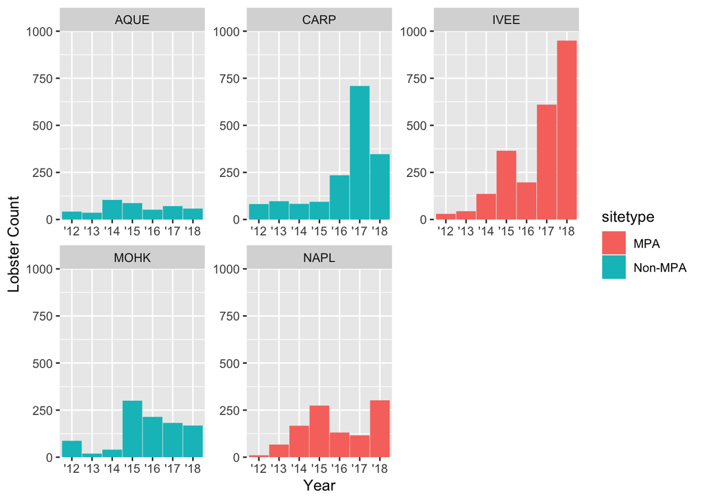

*Figure 1.* *Sample lobster counts from years 2012 - 2018 for MPA and non-MPA sites. MPA sites are colored red while non-MPA are colored blue. Data: Santa Barbara Coastal Long-Term Ecological Research*

### Results B

#### Lobster size distribution in 2012 & 2018

Trends in lobster community size structure were compared in 2012 and 2018: when the Marine Protected Areas were established, and six years after. (Figure 2.) Mean size distribution as well as lobster abundance in the MPA sites (IVEE & NAPL) significantly grew from 2012 to 2018, while mean size distribution did not change significantly in non-MPA sites.

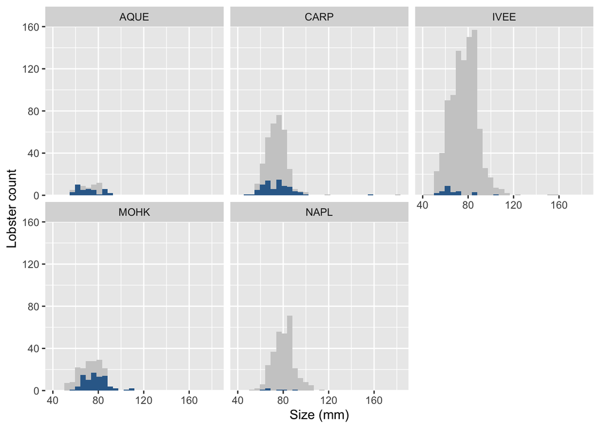

*Figure 2.* *Lobster size sample distribution in 5 different sites from 2012 to 2018. Size (mm) was measured in 5 different sites. Lobster size distribution in 2012 shown in dark blue, while lobster size distribution in 2018 shown in grey. Data: Santa Barbara Coastal Long-Term Ecological Research.*

### Results C

*Table 1.* *Mean lobster size, standard deviation, and sample size in MPA and non-MPA sites for years 2012 and 2018. Data: Santa Barbara Coastal Long-Term Ecological Research.*

| Lobster Size Summary Sitetype | Lobster Size Summary Year | Lobster Size Summary Mean Size | Lobster Size Summary Standard Deviation | Lobster Size Summary Sample Size |
| --- | --- | --- | --- | --- |
| MPA | 2012 | 67.37500 | 12.15425 | 32 |
| MPA | 2018 | 77.56672 | 11.70341 | 1244 |
| Non-MPA | 2012 | 74.92462 | 12.41412 | 199 |
| Non-MPA | 2018 | 73.61996 | 10.09438 | 561 |

##### 1. For 2012 observations, is there a significant difference in lobster size between MPA and non-MPA sites?

Mean lobster size in MPA vs non-MPA sites differed significantly in 2012 (t(42.09) = -3.25, *p* < 0.05). Mean lobster size in non-MPA sites was 11% larger than in MPA sites, with an actual difference of 7.55mm. For lobsters observed in MPA sites in 2012, mean = 67.37mm, n = 32, while lobsters observed in Non-MPA sites in 2012, mean = 74.92mm, n = 199.

##### 2. For 2018 observations, is there a significant difference in lobster size between MPA and non-MPA sites?

Mean lobster size in MPA vs non-MPA sites differed significantly in 2018 (t(1239.51) = 7.31, *p* < 0.05). Mean lobster size in MPA sites was 5% larger than in non-MPA sites, with an actual difference of 3.95mm. Lobsters observed in MPA sites in 2018, mean = 77.57mm, n = 1244, while lobsters observed non-MPA sites mean = 73.62mm, n = 561.

##### 3. For MPA sites only, is there a significant mean size difference in lobsters observed in 2012 vs. 2018?

Mean lobster size in MPA sites differed significantly from 2012 to 2018 (t(32.5) = -4.69, *p* < 0.05). There was a 15% increase in MPA site lobster size from 2012 to 2018, with an actual increase of 10.19mm. For lobster size in MPA sites in 2012, mean = 67.38mm, n = 32, while in MPA sites in 2018 mean size = 77.57mm, n = 1244.

##### 4. For non-MPA sites only, is there a significant mean size difference in lobsters observed in 2012 vs. 2018?

Mean lobster size in non-MPA sites do not differ significantly from 2012 to 2018 (t(296.01) = 1.33, *p* > 0.05). The sample mean lobster size in 2012 non-MPA sites, mean = 74.92mm, n = 199, and sample mean lobster size in 2018 non-MPA sites, mean = 73.62mm, n = 561.

## References

**Reed D. 2019.** *SBC LTER: Reef: Abundance, size and fishing effort for California Spiny Lobster (Panulirus interruptus), ongoing since 2012.* Environmental Data Initiative. https://doi.org/10.6073/pasta/a593a675d644fdefb736750b291579a0. Dataset accessed 11/17/2019.

**Thiault, L., Kernaleguen, L., Osenberg, C. W., Lison de Loma, T., Chancerelle, Y., Siu, G., and Claudet, J.. 2019.** *Ecological evaluation of a marine protected area network: a progressive‐change BACIPS approach.* Ecosphere 10(2).

**Yaeger, K., Culver, C., Schroeter, S., Page, H. (2017).** *Utility of a Collaborative At-Sea Sampling Program (CASP) for the California Spiny Lobster Commercial Fishery: Catch Characteristics and Implications for Management.* Marine and Coastal Fisheries 9(1): 190-202.